# Homework 5

Yi Hang Khor

4/10/2020

## Liquor Sales in Iowa

1. The complete dataset is too large. Download and import the alcohol sales data for Ames only:

```r
dat <- readr::read_csv('2019_Iowa_Liquor_Sales.csv')
```

2. Data cleaning:
1. extract geographic latitude and longitude from the variable `Store Location`

```r
colnames(dat)[8] <- "Store_Location"
dat$Store_Location <- gsub("POINT \\(", "",dat$Store_Location)
dat$Store_Location <- gsub("\\)", "",dat$Store_Location)
dat <- separate(dat, "Store_Location", into = c("Latitude", "Longitude"), sep = " (?=[^ ]+$)")
dat[16:20,8:9]
```

```
## # A tibble: 5 x 2
##   Latitude   Longitude
##   <chr>      <chr>
## 1 -93.650838 42.021461
## 2 <NA>       <NA>
## 3 <NA>       <NA>
## 4 <NA>       <NA>
## 5 -93.611773 42.026938
```

2. make sure the variables are in the correct type, by converting incorrect variable types.

```r
dat$Latitude <- as.numeric(dat$Latitude)
dat$Longitude <- as.numeric(dat$Longitude)
dat$`Vendor Number` <-as.numeric(dat$`Vendor Number`)
str(dat)
```

```
## Classes 'tbl_df', 'tbl' and 'data.frame':    63103 obs. of  25 variables:
##  $ Invoice/Item Number  : chr  "INV-16712000040" "INV-16712000012" "INV-16712000070" "INV-16712000009" ...
##  $ Date                 : chr  "01/03/2019" "01/03/2019" "01/03/2019" "01/03/2019" ...
##  $ Store Number         : num  2500 2500 2500 2500 2500 ...
##  $ Store Name           : chr  "Hy-Vee Food Store #1 / Ames" "Hy-Vee Food Store #1 / Ames" "Hy-Vee Food Store #1 / Ames" "Hy-Vee Food Store #1 / Ames" ...
##  $ Address              : chr  "3800 W Lincoln Way" "3800 W Lincoln Way" "3800 W Lincoln Way" "3800 W Lincoln Way" ...
##  $ City                 : chr  "Ames" "Ames" "Ames" "Ames" ...
##  $ Zip Code             : num  50010 50010 50010 50010 50010 ...
##  $ Latitude             : num  NA NA NA NA NA NA NA NA NA NA ...
##  $ Longitude            : num  NA NA NA NA NA NA NA NA NA NA ...
##  $ County Number        : num  85 85 85 85 85 85 85 85 85 85 ...
##  $ County               : chr  "STORY" "STORY" "STORY" "STORY" ...
##  $ Category             : num  1042100 1012100 1031100 1012100 1081400 ...
##  $ Category Name        : chr  "Imported Dry Gins" "Canadian Whiskies" "American Vodkas" "Canadian Whiskies" ...
##  $ Vendor Number        : num  260 260 55 260 65 205 330 434 260 85 ...
##  $ Vendor Name          : chr  "DIAGEO AMERICAS" "DIAGEO AMERICAS" "SAZERAC NORTH AMERICA" "DIAGEO AMERICAS" ...
##  $ Item Number          : num  28867 11294 37936 10805 82867 ...
##  $ Item Description     : chr  "Tanqueray Gin" "Crown Royal" "Skol Vodka" "Crown Royal Regal Apple" ...
##  $ Pack                 : num  12 24 12 24 12 12 6 6 12 12 ...
##  $ Bottle Volume (ml)   : num  1000 375 750 375 1000 750 1750 1750 750 375 ...
##  $ State Bottle Cost    : num  15.5 8 3.64 8 7.87 ...
##  $ State Bottle Retail  : num  23.25 12 5.46 12 11.81 ...
##  $ Bottles Sold         : num  12 4 12 4 12 3 6 12 2 4 ...
##  $ Sale (Dollars)       : num  279 48 65.5 48 141.7 ...
##  $ Volume Sold (Liters) : num  12 1.5 9 1.5 12 2.25 10.5 21 1.5 1.5 ...
##  $ Volume Sold (Gallons): num  3.17 0.39 2.37 0.39 3.17 0.59 2.77 5.54 0.39 0.39 ...
```

3. extract year, month and day from the variable `Date` as separate columns.

```r
dat <- separate(dat, "Date", into = c("Month","Day","Year"), sep = "/")
dat$Month <- as.numeric(dat$Month)
dat$Day <- as.numeric(dat$Day)
dat$Year <-as.numeric(dat$Year)
str(dat)
```

```
## Classes 'tbl_df', 'tbl' and 'data.frame':    63103 obs. of  27 variables:
##  $ Invoice/Item Number  : chr  "INV-16712000040" "INV-16712000012" "INV-16712000070" "INV-16712000009" ...
##  $ Month                : num  1 1 1 1 1 1 1 1 1 1 ...
##  $ Day                  : num  3 3 3 3 3 3 3 3 9 9 ...
##  $ Year                 : num  2019 2019 2019 2019 2019 ...
##  $ Store Number         : num  2500 2500 2500 2500 2500 ...
##  $ Store Name           : chr  "Hy-Vee Food Store #1 / Ames" "Hy-Vee Food Store #1 / Ames" "Hy-Vee Food Store #1 / Ames" "Hy-Vee Food Store #1 / Ames" ...
##  $ Address              : chr  "3800 W Lincoln Way" "3800 W Lincoln Way" "3800 W Lincoln Way" "3800 W Lincoln Way" ...
##  $ City                 : chr  "Ames" "Ames" "Ames" "Ames" ...
##  $ Zip Code             : num  50010 50010 50010 50010 50010 ...
##  $ Latitude             : num  NA NA NA NA NA NA NA NA NA NA ...
##  $ Longitude            : num  NA NA NA NA NA NA NA NA NA NA ...
##  $ County Number        : num  85 85 85 85 85 85 85 85 85 85 ...
##  $ County               : chr  "STORY" "STORY" "STORY" "STORY" ...
##  $ Category             : num  1042100 1012100 1031100 1012100 1081400 ...
##  $ Category Name        : chr  "Imported Dry Gins" "Canadian Whiskies" "American Vodkas" "Canadian Whiskies" ...
##  $ Vendor Number        : num  260 260 55 260 65 205 330 434 260 85 ...
##  $ Vendor Name          : chr  "DIAGEO AMERICAS" "DIAGEO AMERICAS" "SAZERAC NORTH AMERICA" "DIAGEO AMERICAS" ...
##  $ Item Number          : num  28867 11294 37936 10805 82867 ...
##  $ Item Description     : chr  "Tanqueray Gin" "Crown Royal" "Skol Vodka" "Crown Royal Regal Apple" ...
##  $ Pack                 : num  12 24 12 24 12 12 6 6 12 12 ...
##  $ Bottle Volume (ml)   : num  1000 375 750 375 1000 750 1750 1750 750 375 ...
##  $ State Bottle Cost    : num  15.5 8 3.64 8 7.87 ...
##  $ State Bottle Retail  : num  23.25 12 5.46 12 11.81 ...
##  $ Bottles Sold         : num  12 4 12 4 12 3 6 12 2 4 ...
##  $ Sale (Dollars)       : num  279 48 65.5 48 141.7 ...
##  $ Volume Sold (Liters) : num  12 1.5 9 1.5 12 2.25 10.5 21 1.5 1.5 ...
##  $ Volume Sold (Gallons): num  3.17 0.39 2.37 0.39 3.17 0.59 2.77 5.54 0.39 0.39 ...
```

3. First overview:
1. Plot a scatterplot of lat and long of store locations.

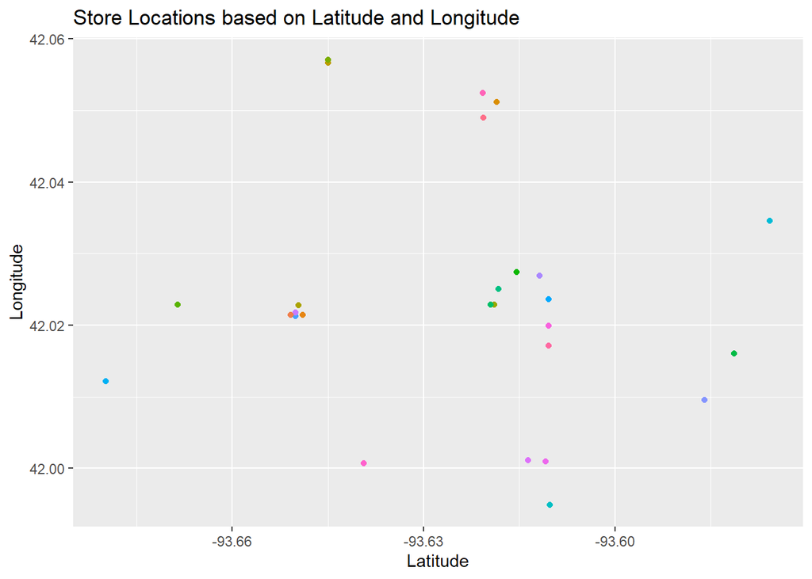

```r
ggplot(dat,aes(x= Latitude,y= Longitude,color = `Store Name`))+geom_point() +xlab("Latitude") +ylab("Longitude") +ggtitle("Store Locations based on Latitude and Longitude") +theme(legend.position = 'none')
```

b. Provide a visual breakdown of the liquor category (by `Category Name`). Include volume sold in the breakdown.

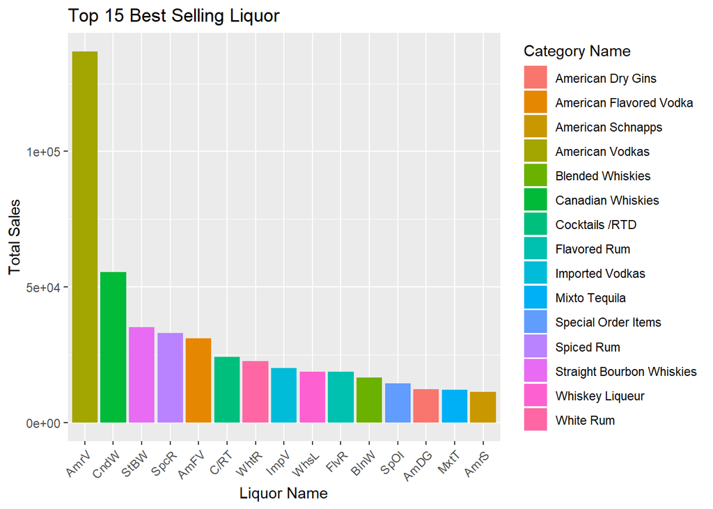

```r
liq <- dat%>%
  group_by(`Category Name`) %>%
  summarize(total= (sum(`Volume Sold (Liters)`))) %>%
  arrange(desc(total))
ggplot(liq[1:15,],aes(x = reorder(`Category Name`,-total),y = `total`,fill = `Category Name`)) +geom_bar(stat= 'identity') +xlab("Liquor Name")+ggtitle("Top 15 Best Selling Liquor") +ylab("Total Sales")+scale_x_discrete(labels = abbreviate) +theme(axis.text.x = element_text(angle = 45, hjust = 1))
```

4. Find the daily sales liquor sales in Ames in 2019. Summarize the number of sales, volume of liquor sold, and amount of money spent.

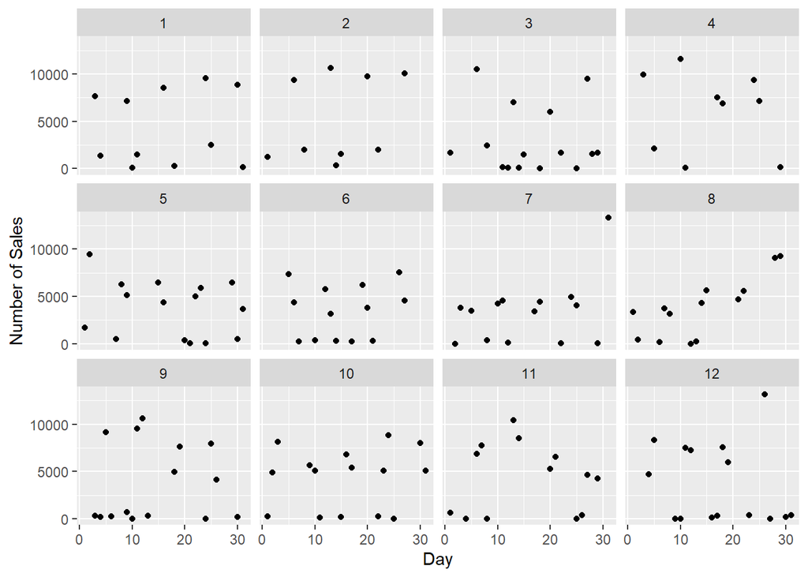

```r
day <- dat %>%
  group_by(`Month`,`Day`) %>%
  summarize(sales = (sum (`Bottles Sold`)),volsold = (sum(`Volume Sold (Liters)`)),spent= (sum(`Sale (Dollars)`)))
ggplot(day,aes(x= Day,y = sales))+geom_point()+facet_wrap(vars(Month)) +ylab("Number of Sales")
```

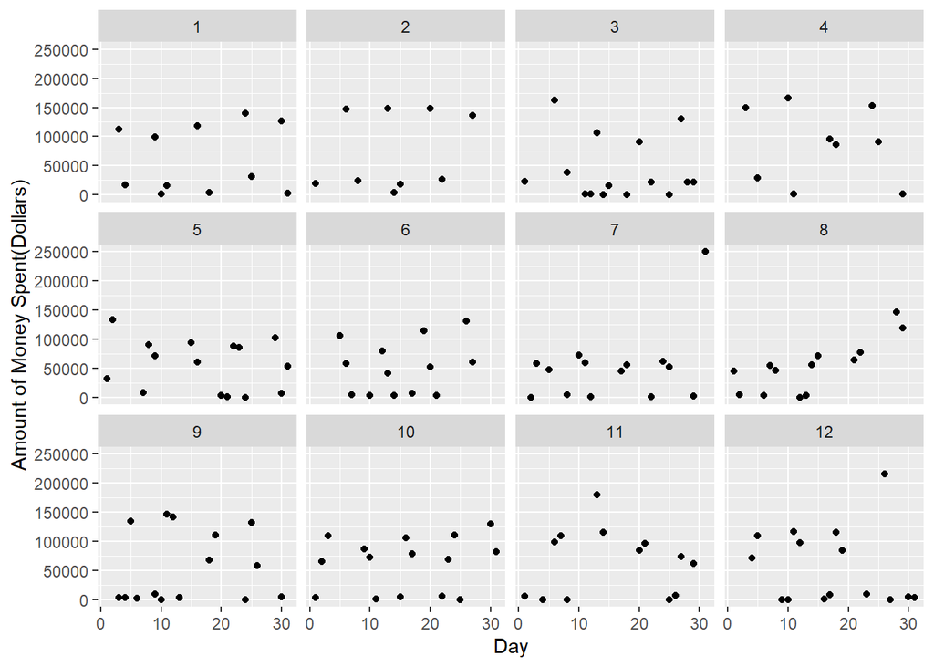

```r
ggplot(day,aes(x= Day,y = spent))+geom_point()+facet_wrap(vars(Month)) +ylab("Amount of Money Spent(Dollars)")
```

5. Plot volume sold by day (use a scatterplot of volume by day and facet by month). Discover trends with the help of `geom_smooth`. Describe any patterns.

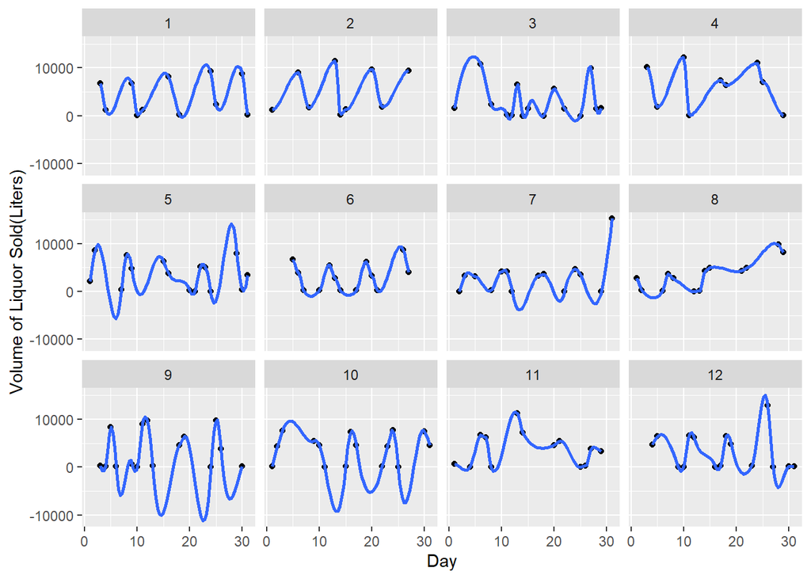

```r
plt <- ggplot(day,aes(x= Day,y = volsold))+geom_point()+facet_wrap(vars(Month)) +ylab("Volume of Liquor Sold(Liters)") +geom_smooth(span = 0.3)
suppressWarnings(print(plt))
```

**Based on the graph, each amplitude (The highest Volume Sold) seems to occur in a weekly interval.**

6. Find the dates for ISU football home games in Fall 2019. Can you see a pattern?

**Iowa State Home Games : 8/31/2019 9/14/2019 9/21/2019 10/5/2019 10/26/2019 11/16/2019 11/23/2019**  
**Due to the lack of data for ISU home games, hence, no pattern can be seen.**